# Capstone Project

David Svancer

# Load Data

The code below will load the tidymodels package and import the *credit_data* tibble from the *modeldata* package.

To keep computation times low, a small random sample of the data is taken.

```r
library(tidymodels)

data("credit_data")

# Take a smaller random sample of the data to speed up computation time
# Target variable is Status - 'bad' or 'good'
set.seed(314)
credit_data <- credit_data %>%
               select(-Time) %>%
               sample_n(700)
```

# Machine Learning Process

The learner will be guided through a complete model development process. We will fit a decision tree classifier to predict whether a customer will have ‘bad’ or ‘good’ credit status.

## Step 1

We will split the data into a training and test set. The training data will be further divided into 5 folds for hyperparameter tuning.

```r
## Create a data split object and training/test sets
set.seed(314)
credit_split <- initial_split(credit_data)

credit_train <- credit_split %>% training()
credit_test <- credit_split %>% testing()

### Create folds for cross validation on the training data set
## These will be used to tune model hyperparameters
set.seed(314)
credit_folds <- vfold_cv(credit_train, v = 5)
```

## Step 2

Next, we specify a decision tree classifier with the following hyperparameters: cost_complexity, tree_depth, and min_n.

```r
tree_model <- decision_tree(cost_complexity = tune(),
                            tree_depth = tune(),
                            min_n = tune()) %>%
              set_engine('rpart') %>%
              set_mode('classification')
```

## Step 3

We will define a blueprint for feature engineering with the recipes packages. For every iteration of cross validation, we will perform the following tasks:

- Impute missing values with KNN
- Transform, center, and scale all numeric predictors
- One-hot encode all nominal variables
- Remove zero variance predictors

```r
credit_recipe <- recipe(Status ~ ., data = credit_train) %>%
                 step_knnimpute(all_predictors()) %>%
                 step_YeoJohnson(all_numeric(), -all_outcomes()) %>%
                 step_center(all_numeric(), -all_outcomes()) %>%
                 step_scale(all_numeric(), -all_outcomes()) %>%
                 step_dummy(all_nominal(), -all_outcomes()) %>%
                 step_zv(all_predictors(), -all_outcomes())
```

## Step 4

Next, we combine our model and recipe into a workflow to easily manage the model-building process.

```r
tree_workflow <- workflow() %>%
                 add_model(tree_model) %>%
                 add_recipe(credit_recipe)
```

## Step 5

Hyperparameter tuning. We will perform a grid search on the decision tree hyperparameters and select the best performing model based on the area under the ROC curve during cross validation.

```r
## Create a grid of hyperparameter values to test
tree_grid <- grid_regular(cost_complexity(),
                          tree_depth(),
                          min_n(),
                          levels = 2)
```

```r
# View grid
tree_grid
```

```
## # A tibble: 8 x 3
##   cost_complexity tree_depth min_n
##             <dbl>      <int> <int>
## 1    0.0000000001          1     2
## 2    0.1                   1     2
## 3    0.0000000001         15     2
## 4    0.1                  15     2
## 5    0.0000000001          1    40
## 6    0.1                   1    40
## 7    0.0000000001         15    40
## 8    0.1                  15    40
```

```r
## Tune decision tree workflow
set.seed(314)
tree_tuning <- tree_workflow %>%
               tune_grid(resamples = credit_folds,
                         grid = tree_grid)
```

```r
## Show the top 5 best models based on roc_auc metric
tree_tuning %>% show_best('roc_auc')
```

```
## # A tibble: 5 x 9
##   cost_complexity tree_depth min_n .metric .estimator  mean     n std_err
##             <dbl>      <int> <int> <chr>   <chr>      <dbl> <int>   <dbl>
## 1    0.0000000001         15    40 roc_auc binary     0.644     5  0.0171
## 2    0.0000000001         15     2 roc_auc binary     0.609     5  0.0131
## 3    0.0000000001          1     2 roc_auc binary     0.545     5  0.0201
## 4    0.0000000001          1    40 roc_auc binary     0.545     5  0.0201
## 5    0.1                   1     2 roc_auc binary     0.5       5  0
## # … with 1 more variable: .config <chr>
```

```r
## Select best model based on roc_auc
best_tree <- tree_tuning %>%
             select_best(metric = 'roc_auc')


## Finalize workflow by adding the best performing model
final_tree_workflow <- tree_workflow %>%
                       finalize_workflow(best_tree)
```

## Step 6

Next we fit our final model workflow to the training data and evaluate performance on the test data.

The `last_fit()` function will fit our workflow to the training data and generate predictions on the test data as defined by our *credit_split* `rsample` object.

```r
tree_fit <- final_tree_workflow %>%
            last_fit(credit_split)
```

We can view our performance metrics on the test data

```r
tree_fit %>% collect_metrics()
```

```
## # A tibble: 2 x 3
##   .metric  .estimator .estimate
##   <chr>    <chr>          <dbl>
## 1 accuracy binary         0.737
## 2 roc_auc  binary         0.689
```

We can plot the ROC curve to visualize test set performance of our tuned decision tree

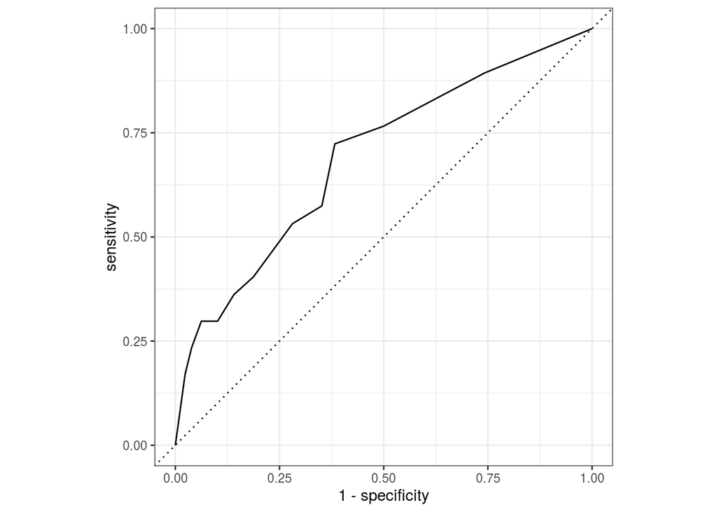

```r
tree_fit %>% collect_predictions() %>%
             roc_curve(truth  = Status, estimate = .pred_bad) %>%
             autoplot()
```